# EXPLORATION OF LOAN DATA FROM PROSPER

By Mai Nguyen

> About: Prosper is a peer-to-peer lending platform that aims to connect people who need money with those people who have the money to invest. Dataset: The Prosper loan data set contains 113,937 loans with 81 variables on each loan, including loan amount, borrower rate (or interest rate), current loan status, borrower income, and many others.

# Univariate Plots Section

```
## [1] 113937     81
```

```
## 'data.frame':    113937 obs. of  81 variables:
##  $ ListingKey                         : Factor w/ 113066 levels "00003546482094282EF90E5",..: 7180 7193 6647 6669 6686 6689 6699 6706 6687 6687 ...
##  $ ListingNumber                      : int  193129 1209647 81716 658116 909464 1074836 750899 768193 1023355 1023355 ...
##  $ ListingCreationDate                : Factor w/ 113064 levels "2005-11-09 20:44:28.847000000",..: 14184 111894 6429 64760 85967 100310 72556 74019 97834 97834 ...
##  $ CreditGrade                        : Factor w/ 9 levels "","A","AA","B",..: 5 1 8 1 1 1 1 1 1 1 ...
##  $ Term                               : int  36 36 36 36 36 60 36 36 36 36 ...
##  $ LoanStatus                         : Factor w/ 12 levels "Cancelled","Chargedoff",..: 3 4 3 4 4 4 4 4 4 4 ...
##  $ ClosedDate                         : Factor w/ 2803 levels "","2005-11-25 00:00:00",..: 1138 1 1263 1 1 1 1 1 1 1 ...
##  $ BorrowerAPR                        : num  0.165 0.12 0.283 0.125 0.246 ...
##  $ BorrowerRate                       : num  0.158 0.092 0.275 0.0974 0.2085 ...
##  $ LenderYield                        : num  0.138 0.082 0.24 0.0874 0.1985 ...
##  $ EstimatedEffectiveYield            : num  NA 0.0796 NA 0.0849 0.1832 ...
##  $ EstimatedLoss                      : num  NA 0.0249 NA 0.0249 0.0925 ...
##  $ EstimatedReturn                    : num  NA 0.0547 NA 0.06 0.0907 ...
##  $ ProsperRating..numeric.            : int  NA 6 NA 6 3 5 2 4 7 7 ...
```

[output cut: 67 more lines]

```
##                    ListingKey     ListingNumber
##  17A93590655669644DB4C06:     6   Min.   :      4
##  349D3587495831350F0F648:     4   1st Qu.: 400919
##  47C1359638497431975670B:     4   Median : 600554
##  8474358854651984137201C:     4   Mean   : 627886
##  DE8535960513435199406CE:     4   3rd Qu.: 892634
##  04C13599434217079754AEE:     3   Max.   :1255725
##  (Other)                :113912
##                     ListingCreationDate  CreditGrade         Term
##  2013-10-02 17:20:16.550000000:     6          :84984   Min.   :12.00
##  2013-08-28 20:31:41.107000000:     4   C      : 5649   1st Qu.:36.00
##  2013-09-08 09:27:44.853000000:     4   D      : 5153   Median :36.00
##  2013-12-06 05:43:13.830000000:     4   B      : 4389   Mean   :40.83
##  2013-12-06 11:44:58.283000000:     4   AA     : 3509   3rd Qu.:36.00
##  2013-08-21 07:25:22.360000000:     3   HR     : 3508   Max.   :60.00
##  (Other)                      :113912   (Other): 6745
##                  LoanStatus                  ClosedDate
##  Current              :56576                      :58848
##  Completed            :38074   2014-03-04 00:00:00:  105
##  Chargedoff           :11992   2014-02-19 00:00:00:  100
##  Defaulted            : 5018   2014-02-11 00:00:00:   92
##  Past Due (1-15 days) :  806   2012-10-30 00:00:00:   81
##  Past Due (31-60 days):  363   2013-02-26 00:00:00:   78
##  (Other)              : 1108   (Other)            :54633
##   BorrowerAPR       BorrowerRate     LenderYield
##  Min.   :0.00653   Min.   :0.0000   Min.   :-0.0100
##  1st Qu.:0.15629   1st Qu.:0.1340   1st Qu.: 0.1242
##  Median :0.20976   Median :0.1840   Median : 0.1730
##  Mean   :0.21883   Mean   :0.1928   Mean   : 0.1827
##  3rd Qu.:0.28381   3rd Qu.:0.2500   3rd Qu.: 0.2400
##  Max.   :0.51229   Max.   :0.4975   Max.   : 0.4925
##  NA's   :25
##  EstimatedEffectiveYield EstimatedLoss   EstimatedReturn
##  Min.   :-0.183          Min.   :0.005   Min.   :-0.183
##  1st Qu.: 0.116          1st Qu.:0.042   1st Qu.: 0.074
##  Median : 0.162          Median :0.072   Median : 0.092
##  Mean   : 0.169          Mean   :0.080   Mean   : 0.096
##  3rd Qu.: 0.224          3rd Qu.:0.112   3rd Qu.: 0.117
##  Max.   : 0.320          Max.   :0.366   Max.   : 0.284
##  NA's   :29084           NA's   :29084   NA's   :29084
```

[output cut: 193 more lines]

```
##  Min.   :    0.00                Min.   :0.7000   Min.   : 0.00000
##  1st Qu.:    0.00                1st Qu.:1.0000   1st Qu.: 0.00000
##  Median :    0.00                Median :1.0000   Median : 0.00000
##  Mean   :   25.14                Mean   :0.9986   Mean   : 0.04803
##  3rd Qu.:    0.00                3rd Qu.:1.0000   3rd Qu.: 0.00000
##  Max.   :21117.90                Max.   :1.0125   Max.   :39.00000
##
##  InvestmentFromFriendsCount InvestmentFromFriendsAmount   Investors
##  Min.   : 0.00000           Min.   :    0.00            Min.   :   1.00
##  1st Qu.: 0.00000           1st Qu.:    0.00            1st Qu.:   2.00
##  Median : 0.00000           Median :    0.00            Median :  44.00
##  Mean   : 0.02346           Mean   :   16.55            Mean   :  80.48
##  3rd Qu.: 0.00000           3rd Qu.:    0.00            3rd Qu.: 115.00
##  Max.   :33.00000           Max.   :25000.00            Max.   :1189.00
##
```

> Our dataset consists of 81 variables with almost 114000 observations. The central question of this exploratory analysis is the relationship between different variables with whether the loan is completed or bad.

```r
#  We can see that there are 25 loans with missing BorrowerAPR. Borrower ARP is equal to Borrower Rate plus other fees. We calculate the borrower fees as the difference between APR and Rate, and add the median of borrower fees to Borrower Rate to fill in missing Borrower ARP values.

df$borrower_fees <- df$BorrowerAPR - df$BorrowerRate

df$BorrowerAPR <- ifelse(is.na(df$BorrowerAPR), df$BorrowerRate + median(df$borrower_fees, na.rm = TRUE), df$BorrowerAPR)

# Fill in missing EstimatedEffectiveYield values. EstimatedEffectiveYield is equal to Borrower Rate minus some loss from fees. The approach is similar to filling in missing BorrowerAPR above.
df$estimated_loss_from_fees <- df$BorrowerRate - df$EstimatedEffectiveYield

df$EstimatedEffectiveYield <- ifelse(is.na(df$EstimatedEffectiveYield), df$BorrowerRate - median(df$estimated_loss_from_fees, na.rm = TRUE), df$EstimatedEffectiveYield)

# Fill in missing EstimatedLoss values by median values of estimated loss:
df$EstimatedLoss <- ifelse(is.na(df$EstimatedLoss), median(df$EstimatedLoss, na.rm = TRUE), df$EstimatedLoss)

# Fill in missing EstimatedReturn values by the difference between EstimatedEffectiveYield and EstimatedLoss:
df$EstimatedReturn <- ifelse(is.na(df$EstimatedReturn), df$EstimatedEffectiveYield - df$EstimatedLoss, df$EstimatedReturn)

# Fill in missing ProsperRating (numeric) and Prosper Score
df$ProsperRating..numeric.<-ifelse(is.na(df$ProsperRating..numeric.), median(df$ProsperRating..numeric., na.rm = TRUE), df$ProsperRating..numeric.)

df$ProsperScore <- ifelse(is.na(df$ProsperScore), median(df$ProsperScore, na.rm = TRUE), df$ProsperScore)

# We notice that missing DebtToRatio values exist in rows with unverifiable incomes. Calculate DebtToIncomeRatio for theses data points, adding $0.1 to account for $0/month incomes:
df$DebtToIncomeRatio <- ifelse(is.na(df$DebtToIncomeRatio), df$MonthlyLoanPayment / (df$StatedMonthlyIncome + 0.1), df$DebtToIncomeRatio)
```

> Now we explore LoanStatus, the main dependent variable of our analysis.

```
##
##              Cancelled             Chargedoff              Completed
##                      5                  11992                  38074
##                Current              Defaulted FinalPaymentInProgress
##                  56576                   5018                    205
##   Past Due (>120 days)   Past Due (1-15 days)  Past Due (16-30 days)
##                     16                    806                    265
##  Past Due (31-60 days)  Past Due (61-90 days) Past Due (91-120 days)
##                    363                    313                    304
```

> To effectively answer the central question, we need to define completed and bad loans. For simplicity, we assume all the “Past Due”, “ChargedOff”, “FinalPaymentInProgress” and “Cancellation” loans as bad loans. We remove “Current loans” as there is no information to infer whether these loans will be completed or not. After that, we encode completed loans as 1, and bad loans as 0.

```r
df <- subset(df, df$LoanStatus != "Current")

df$LoanStatus <- ifelse(df$LoanStatus == 'Completed', 1, 0)
```

```r
dim(df)
```

```
## [1] 57361    83
```

> Now our dataset has 57361 observations remaining. We move on to creating some univariate exploratory plots.

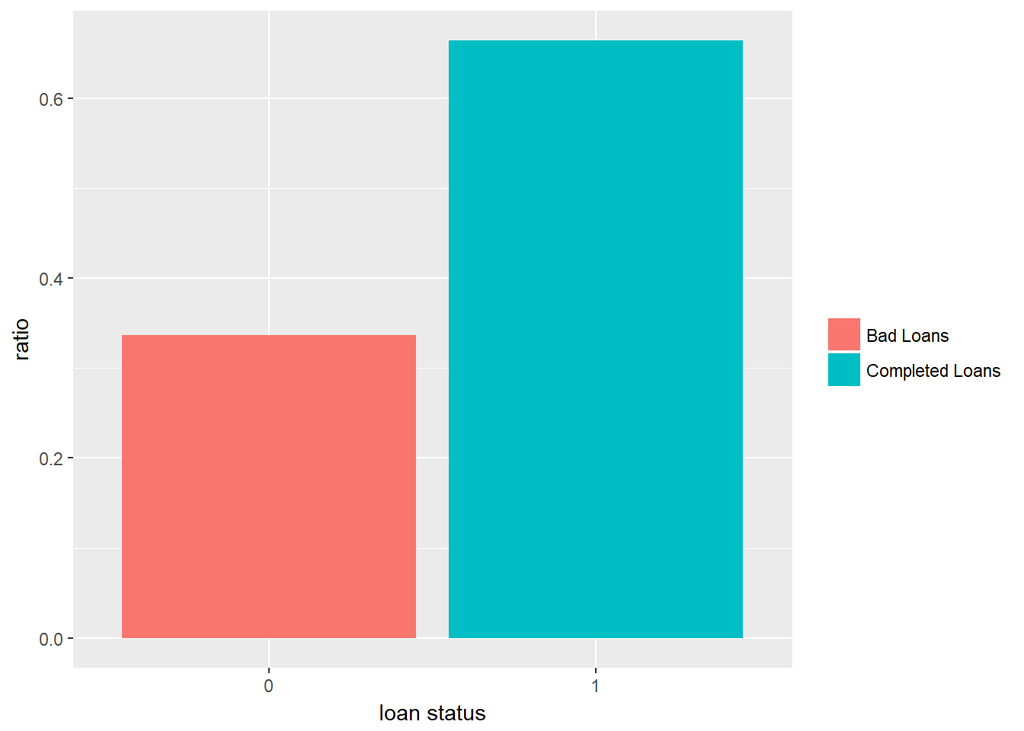

```r
mean(df$LoanStatus)*100
```

```
## [1] 66.37611
```

> **Financial Information**: We first explore 7 variables relating to financial information of borrowers, including: EmploymentStatus, EmploymentStatusDuration, StatedMonthly Income, DebttoIncomeRatio, AvailableaBankcardCredit, BankcardUtilization, IsBorrowerHomeowner.

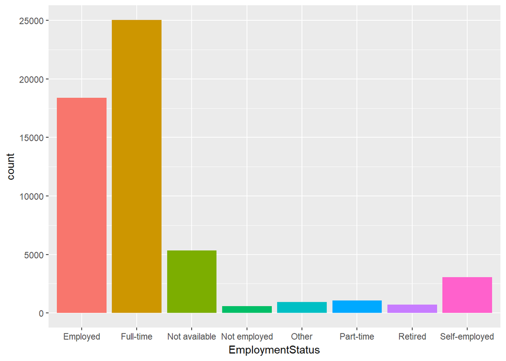

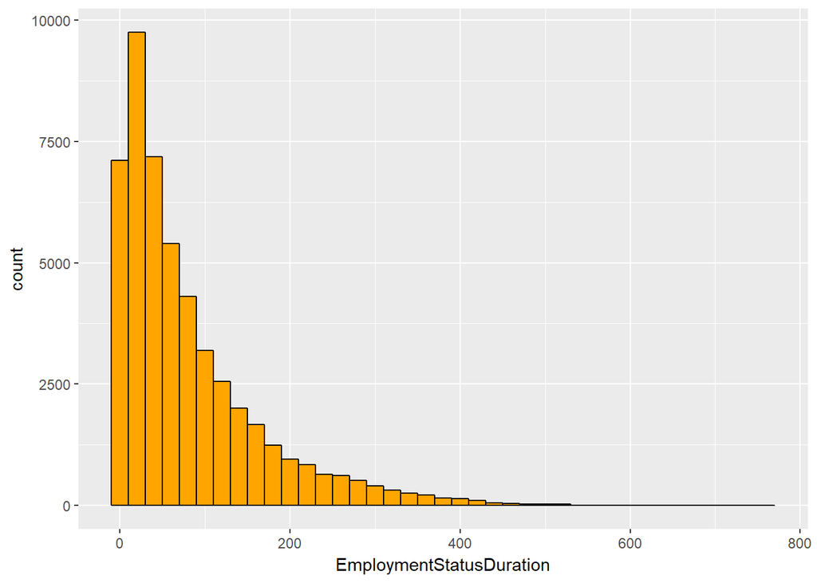

> EmploymentStatusDuration is skewed to the right with the long tail. We limit our analysis from 0 to 500.

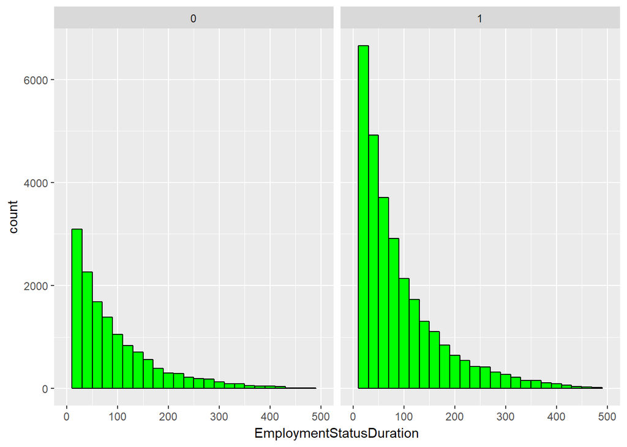

```
## df$LoanStatus: 0
##    Min. 1st Qu.  Median    Mean 3rd Qu.    Max.    NA's
##    0.00   20.00   53.00   82.35  115.00  755.00    3089
## --------------------------------------------------------
## df$LoanStatus: 1
##    Min. 1st Qu.  Median    Mean 3rd Qu.    Max.    NA's
##    0.00   21.00   53.00   81.26  112.00  745.00    4526
```

> The distributions of employment status duration in the two groups are quite similar.

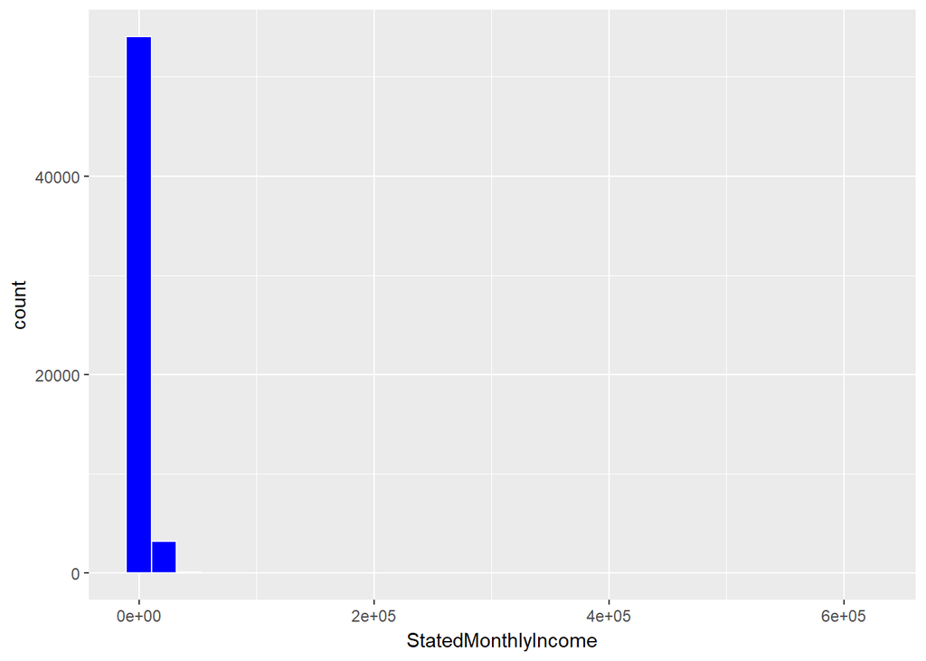

```
##    Min. 1st Qu.  Median    Mean 3rd Qu.    Max.
##       0    2833    4167    5070    6250  618548
```

> StatedMonthlyIncome is highly skewed to the right, with the 3rd quantile value at 6250 but the max value of 618548. We use the log 10 base to transform it in order to see the distribution better.

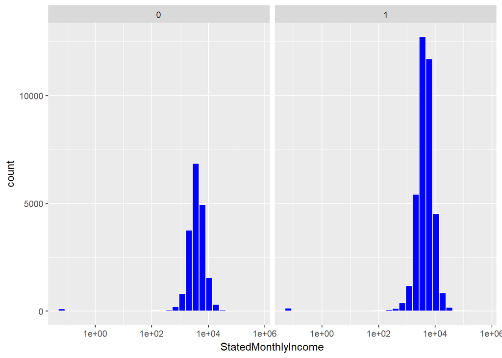

```r
by(df$StatedMonthlyIncome, df$LoanStatus, summary)
```

```
## df$LoanStatus: 0
##    Min. 1st Qu.  Median    Mean 3rd Qu.    Max.
##       0    2500    3792    4568    5667  208333
## --------------------------------------------------------
## df$LoanStatus: 1
##    Min. 1st Qu.  Median    Mean 3rd Qu.    Max.
##       0    2917    4417    5324    6583  618548
```

> We can see that in the group of completed loans, borrowers appear to have higher stated monthly income.

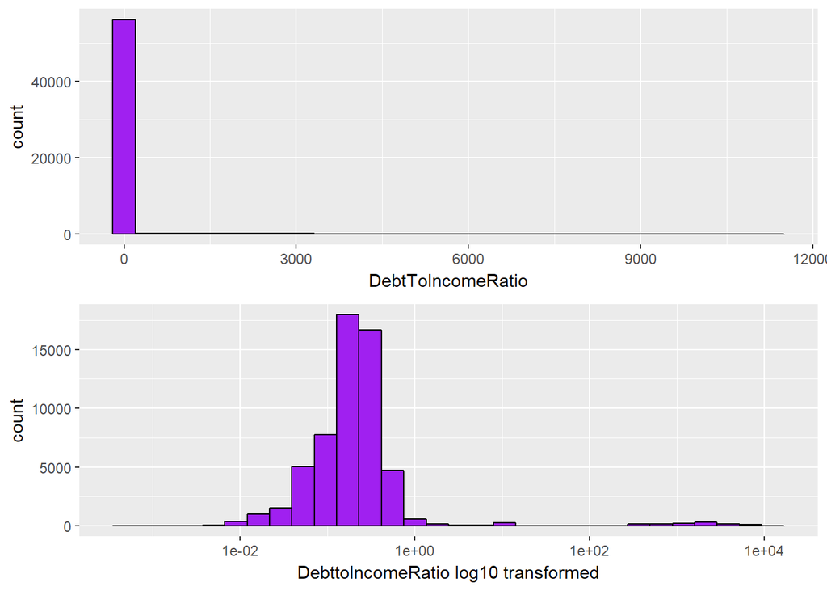

> Debt to Income ratio is highly to the right, so we transform it using the log 10 base.

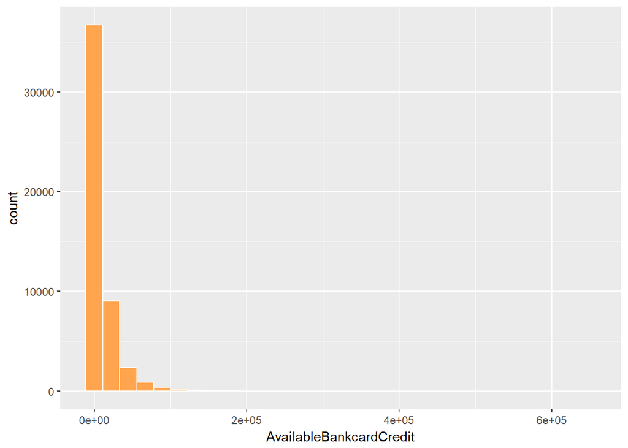

> We also transform AvailableBankcardCredit using log 10 base.

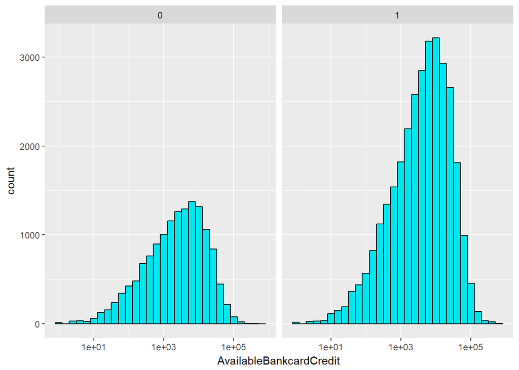

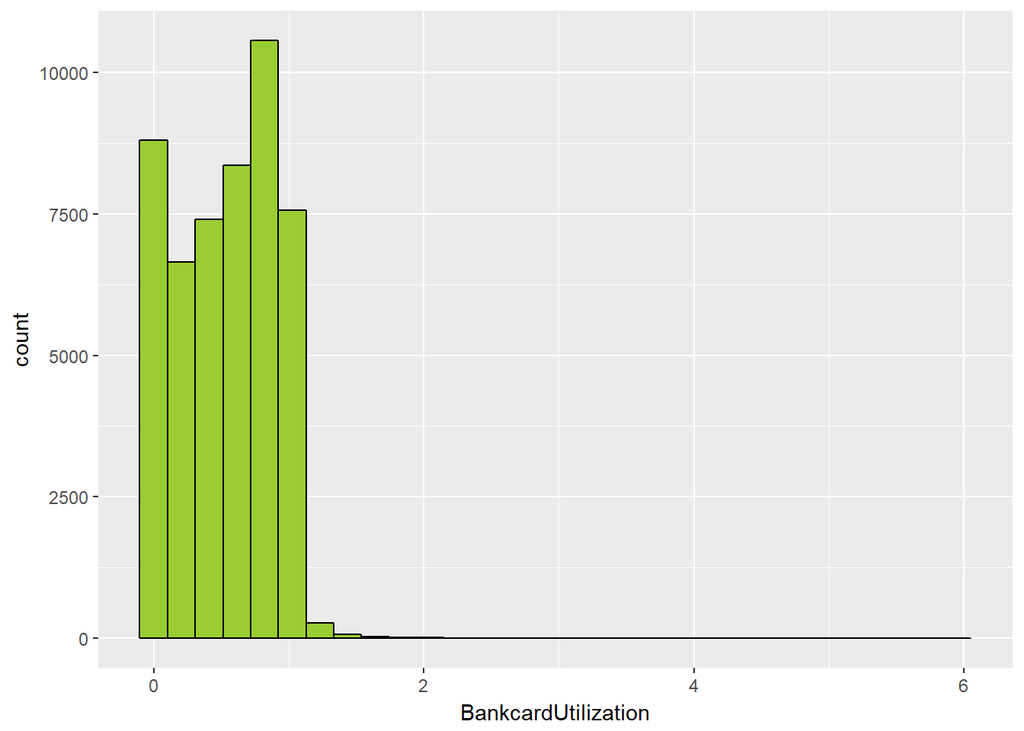

> We limit BankcardUlilization from 0 to 2.5.

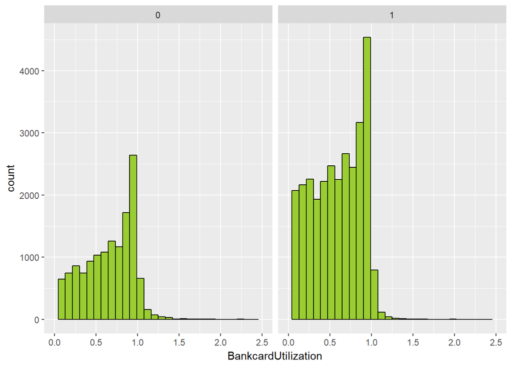

```r
by(df$BankcardUtilization, df$LoanStatus, summary)
```

```
## df$LoanStatus: 0
##    Min. 1st Qu.  Median    Mean 3rd Qu.    Max.    NA's
##  0.0000  0.2500  0.6250  0.5665  0.8900  4.7300    3087
## --------------------------------------------------------
## df$LoanStatus: 1
##    Min. 1st Qu.  Median    Mean 3rd Qu.    Max.    NA's
##   0.000   0.210   0.540   0.516   0.830   5.950    4517
```

> It apprears that bank card utilization is more concentrated on the lower levels in the group of completed loans.

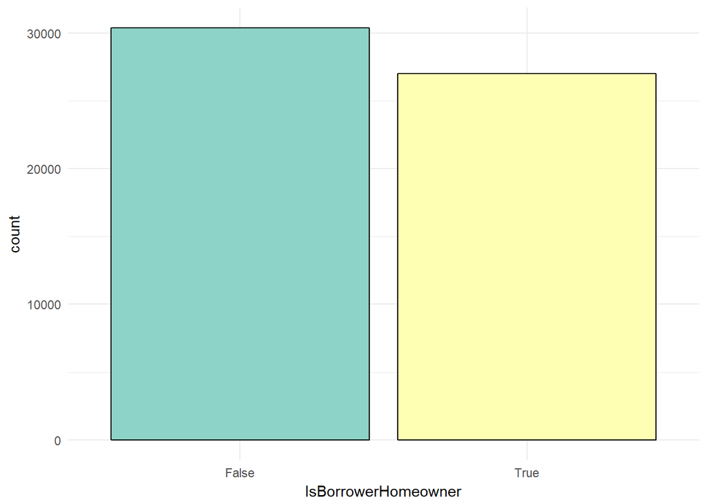

> **Credit History** : Next, we explore credit history of borrowers, including 4 variables: CurrentCreditLines, TotalCreditLinespast7years, CurrentDeliquencies, Delinquenciespast7years.

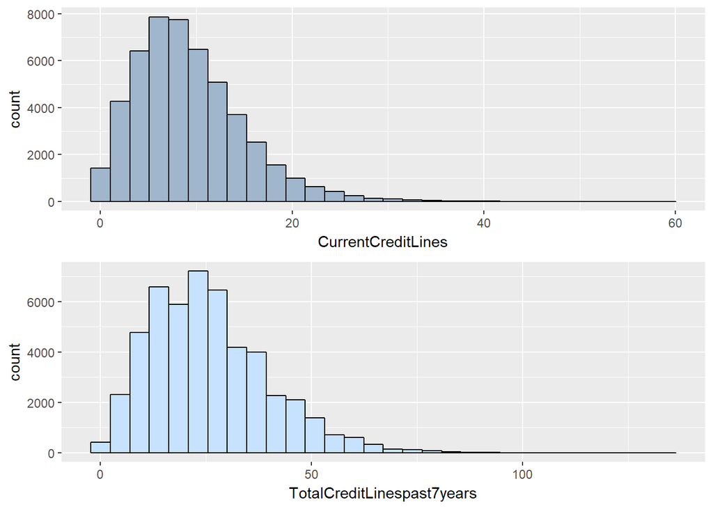

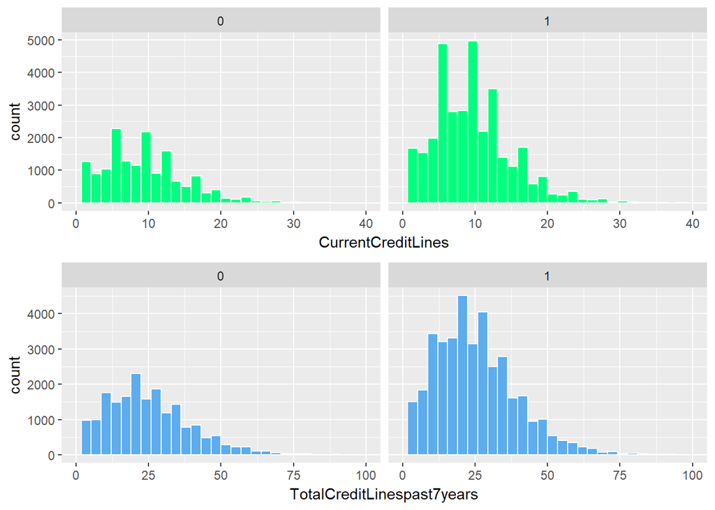

> The distribution of credit lines appears to be similar between completed and bad loans.

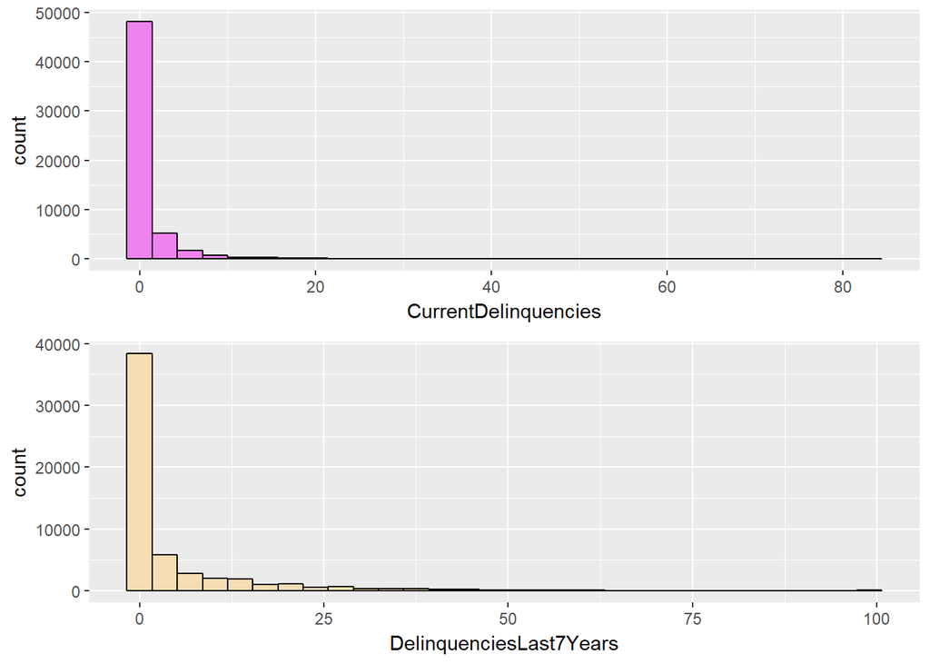

> We limit CurrentDelinquencies to 5 and DelinquenciesLast7Years to 20.

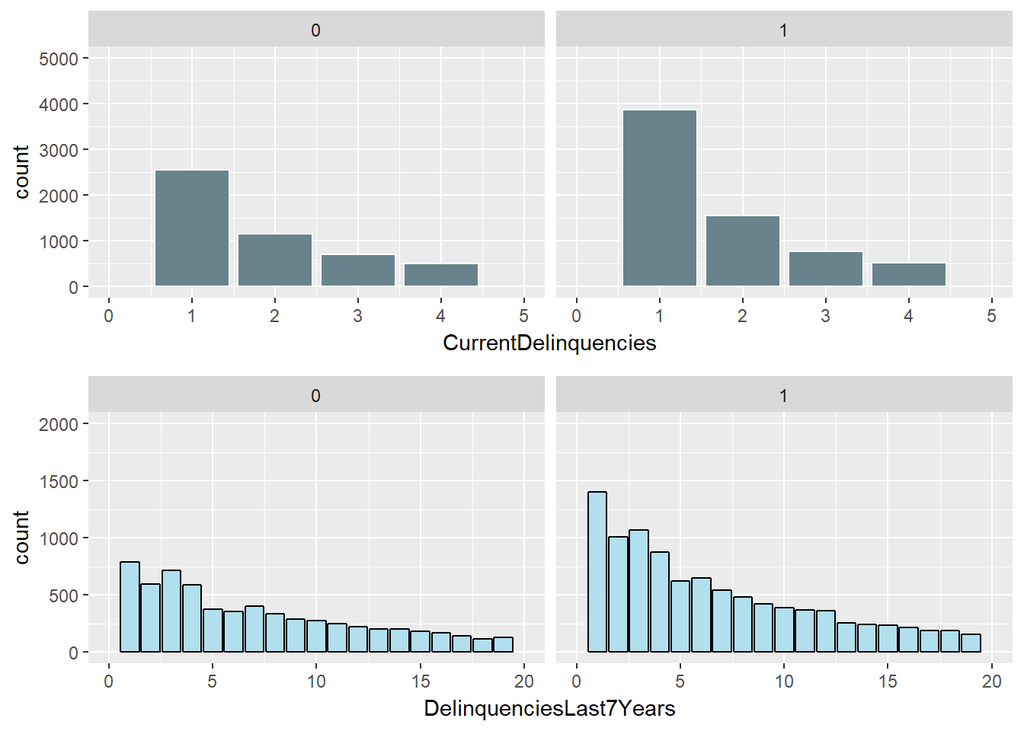

> In the group of completed loans, deliquencies seem to be more concentrated on the lower level.

> **Credit Score**: Credit Score is the next set of variables to explore, including: ProsperRating (numeric), ProsperScore, CreditScoreRangeLower, CreditScoreRangeUpper.

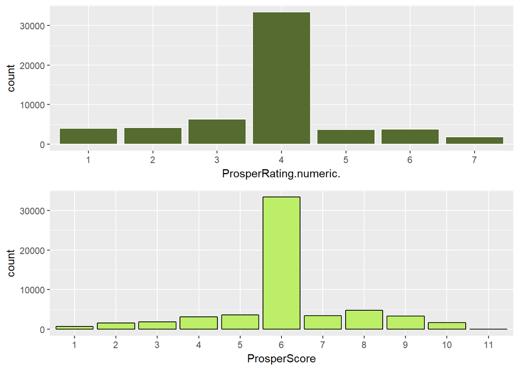

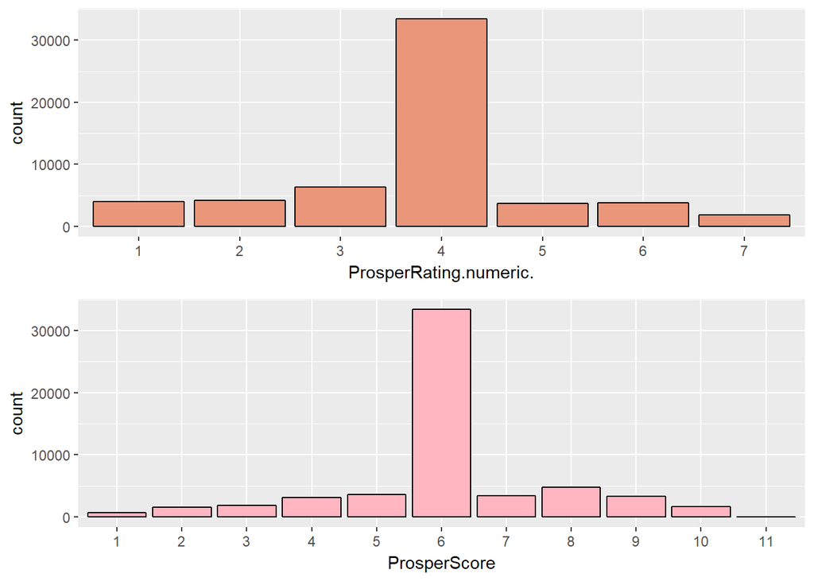

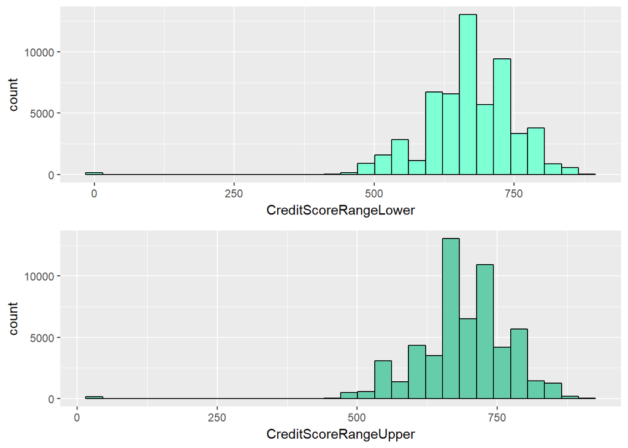

> The histogram of CreditScoreRangeLower and CreditScoreRangeUpper looks very similar.

> **Loan Characteristics**: The final set of variables to be explored relate to the characteristics of the loans, comprising: LoanOriginalAmount, Term and BorrowerRate.

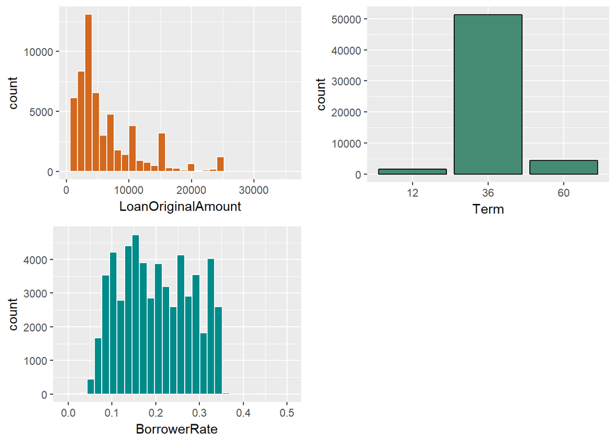

> We limit BorrowerRate from 0 to 0.4 in our analysis:

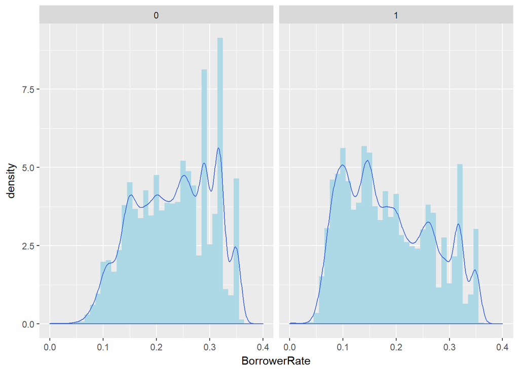

> From the above histogram, we can see that BorrowerRate in the group of completed loans concentrate more on the lower side compared to the group of bad loans.

# Univariate Analysis

### The structure of the dataset?

> The processed dataset contains the data on 57361 loans with 2 statuses: Completed (66,37% of the loans) and Bad (33,63%).

### The main features of interest in thr dataset?

> The dependent variable in this analysis is the binary variable of Loan Status, whether the loan is completed or bad. I am interested in whether variables relating to financial information, credit history, credit score and loan characteristics can predict the loan status.

### Other features in the dataset that will help support the investigation into the feature(s) of interest?

> Some variables that appear to have correlation with Loan Status from this univariate analysis are Borrower Rate, Deliquencies, Bankcard Utilization, Stated Monthly Income, Employment Status Duration. The correlation will be further explored explored in the Bivariate Exploratoty Plots section.

### Any new variables created from existing variables in the dataset?

I transformed the categorical Loan Status variable into a binary variable with 1 representing completed loans and 0 representing bad loans.

### Of the features investigated, were there any unusual distributions? Did you perform any operations on the data to tidy, adjust, or change the form of the data? If so, why did you do this?

> I log-transformed the StatedMonthlyIncome, Debt to Income Ratio and AvailableBankcardCredit and limit the range of some variables that are skewed to the right. I also filled in missing values of some variables.

# Bivariate Plots Section

> **Financial Infornation and Loan Status**

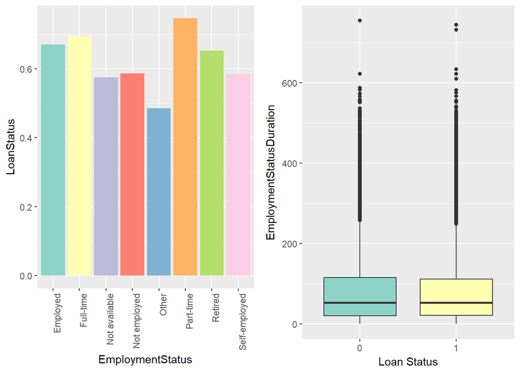

> Regarding Employment Status, we can see that there is variation in terms of Loan Status between different groups. Noticably, part-time workers completed loans more than full-time workers. There appreas to be no correlation between loan status and employment status duration. We confirm the weak correlation between Employment Status Duration and Loan Status by calculating the Pearson correlation coefficient below, which is not statistically significant.

```
##
##  Pearson's product-moment correlation
##
## data:  df$LoanStatus and df$EmploymentStatusDuration
## t = -1.3415, df = 49744, p-value = 0.1798
## alternative hypothesis: true correlation is not equal to 0
## 95 percent confidence interval:
##  -0.014801529  0.002773061
## sample estimates:
##          cor
## -0.006014698
```

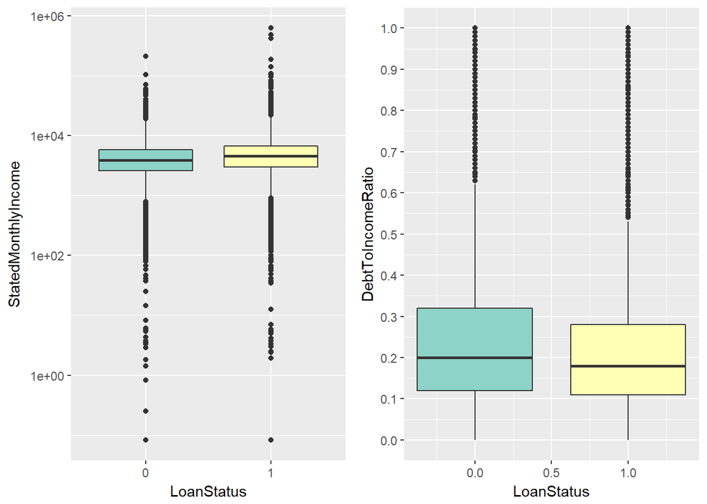

> Higher stated monthly income and lower debt to income ratio appears to be correlated with higher rate of completed loans.

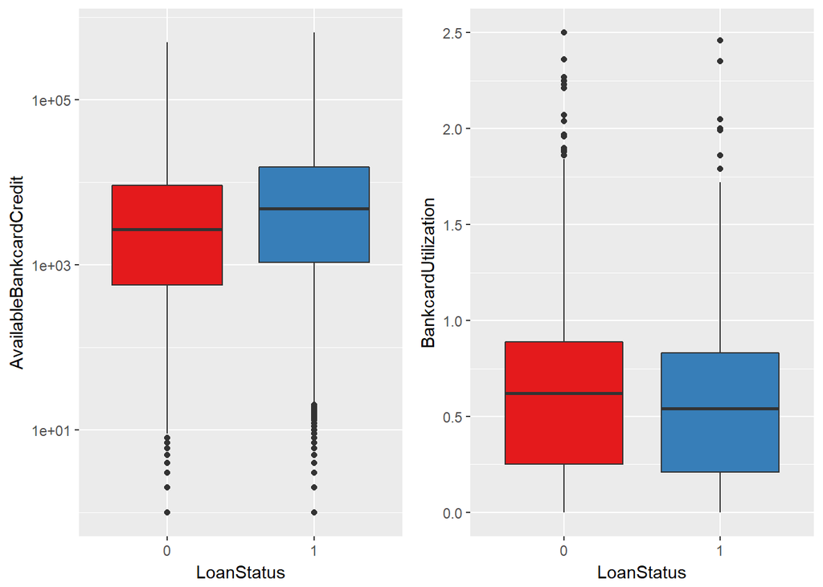

> Higher available bank credit and lower bank card utilization is showned in the above plots to be characteristics of borrowers of completed loans.

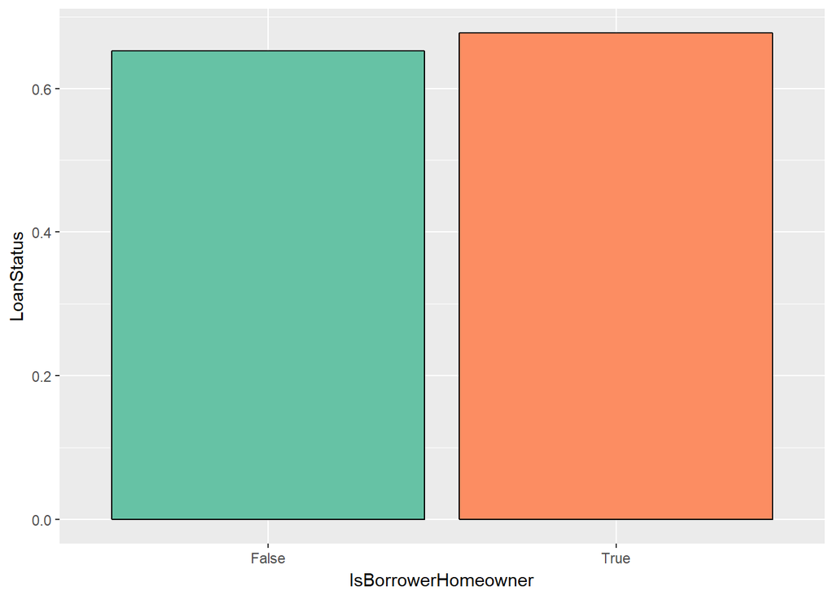

> It seems homeowners default or have bad loans very slightly less often than renters.

> **Credit History and Loan Status**:

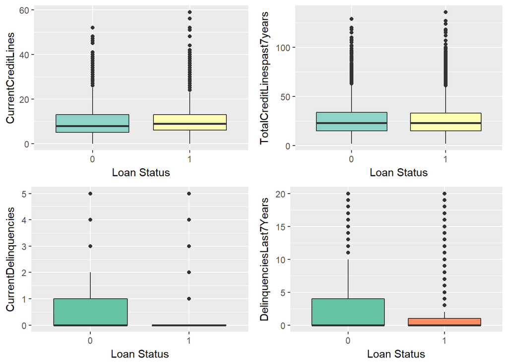

> Number of credit lines doesn’t appear to have relationship with default. Regarding delinquencies, among loans that were completed, it is rare for the borrower to have any current delinquencies and a similar trend is observed with deliquencies over last 7 years. Let’s examine the correlation.

```
##
##  Pearson's product-moment correlation
##
## data:  df$CurrentDelinquencies and df$LoanStatus
## t = -39.007, df = 56662, p-value < 2.2e-16
## alternative hypothesis: true correlation is not equal to 0
## 95 percent confidence interval:
##  -0.1697209 -0.1536841
## sample estimates:
##        cor
## -0.1617132
```

```
##
##  Pearson's product-moment correlation
##
## data:  df$DelinquenciesLast7Years and df$LoanStatus
## t = -20.482, df = 56369, p-value < 2.2e-16
## alternative hypothesis: true correlation is not equal to 0
## 95 percent confidence interval:
##  -0.09413932 -0.07775109
## sample estimates:
##         cor
## -0.08595102
```

> The correlation between both current deliquencies and historical deliquencies with loan status are statistically significant, with p-value <0.01.

> **Credit Score and Loan Status**:

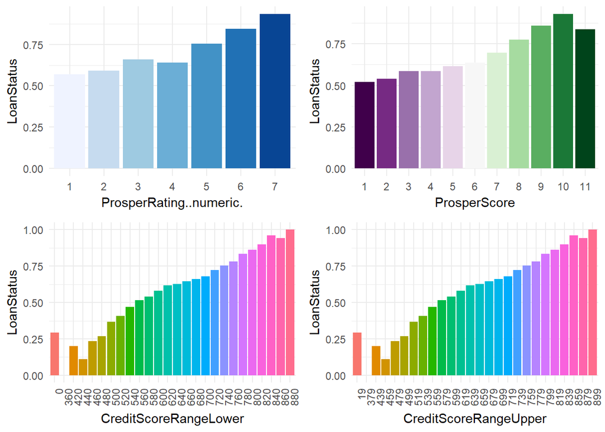

> The probability of having default or bad loans seems to be lower for higher credit score, prosper rating and prosper score. There are some exceptions, for example, debtors with prosper score of 11 have more bad loans than those with that of 10. The correlation coefficient between CreditScoreRangeLower and Loan Status is 0.228 and sigificant.

```
##
##  Pearson's product-moment correlation
##
## data:  df$CreditScoreRangeLower and df$LoanStatus
## t = 55.873, df = 56768, p-value < 2.2e-16
## alternative hypothesis: true correlation is not equal to 0
## 95 percent confidence interval:
##  0.2204996 0.2360941
## sample estimates:
##       cor
## 0.2283115
```

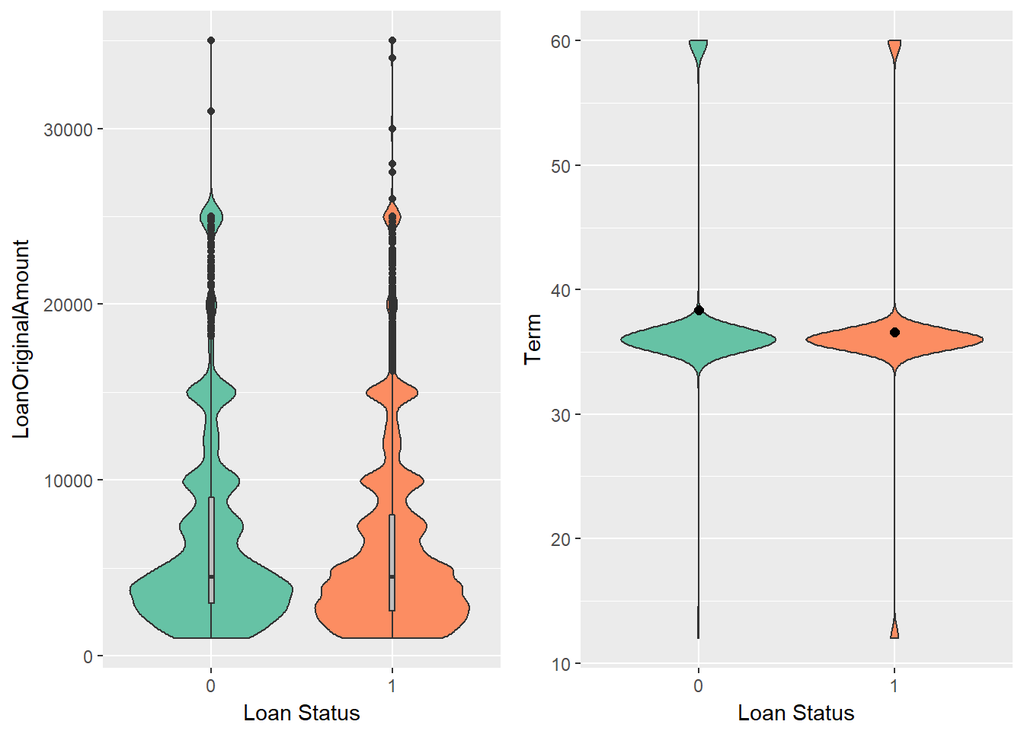

> The distributions of loan orignial amount and term seem to be consistent whether the loan is completed or not. It is noticeable that the mean term of bad loans is higher than that of completed loans.

> **Create Correlation Matrix**:

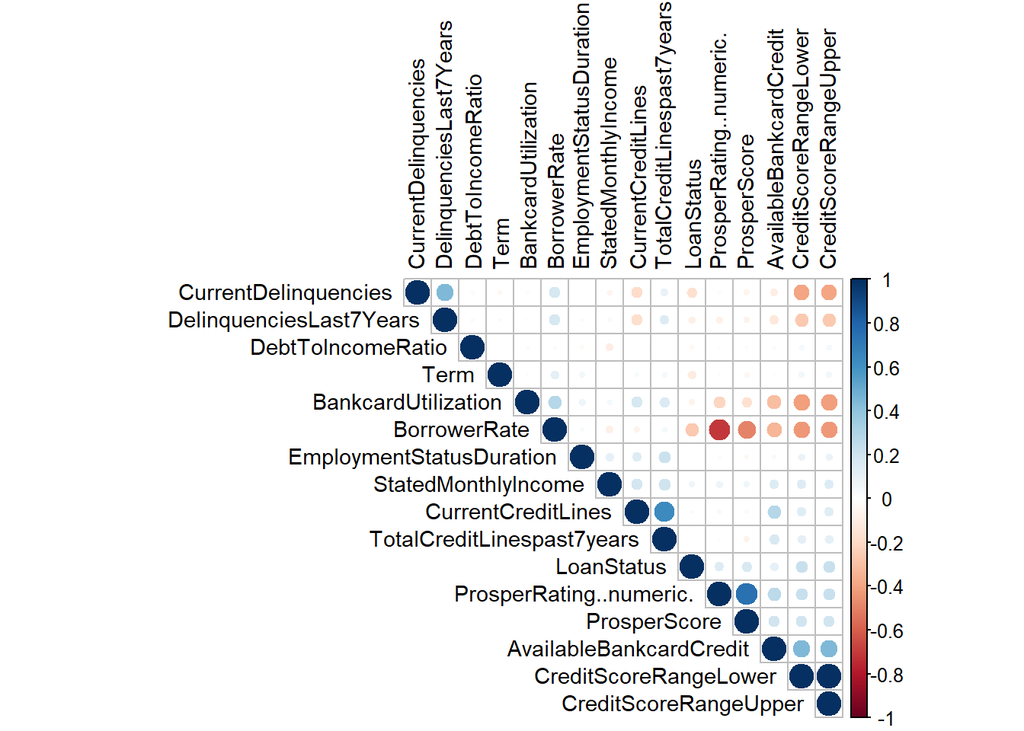

# Bivariate Analysis

### Some of the relationships you observed in this part of the investigation. How did the feature(s) of interest vary with other features in the dataset?

> Loan Status is found to be significantly correlated with Borrower Rate, Term, CurrentDeliquencies, DeliquenciesLast7Years, StatedMonthlyIncome, Prosper Rating, Prosper Score, AvailableBankCredit, BankcardUtilization, CreditScoreRangeLower. CreditScoreRangeUpper.

### Any interesting relationships between the other features (not the main feature(s) of interest)?

# Multivariate Plots Section

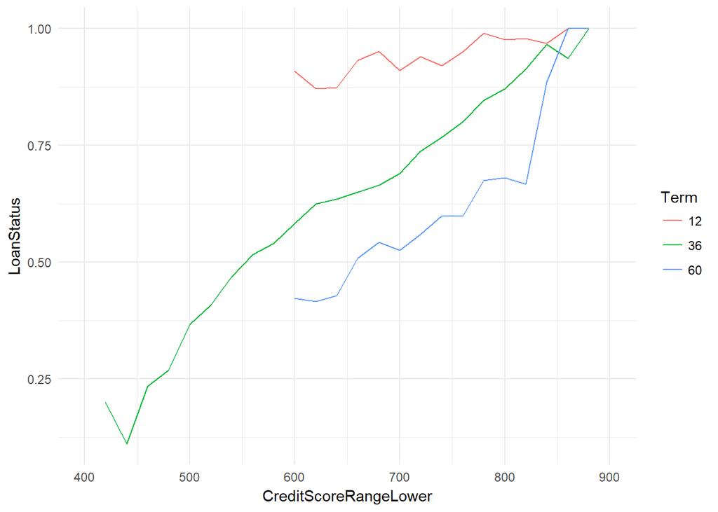

> From the above plot, it appears that higher credit score and shorter term of loan is correlated with higher probability of completing the loans. The correlation between credit score and loan status seems to be quite consistent across loans with different terms.

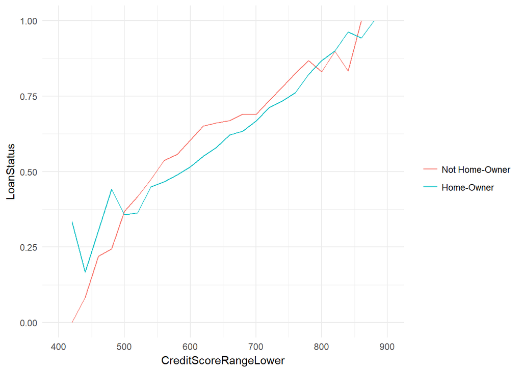

> The positive correlation between Credit score and the probability is also assistent between Home Oweners and Non-Homeoweners groups of borrowers, but there is little difference between these two group is terms of probability of completing the loans.

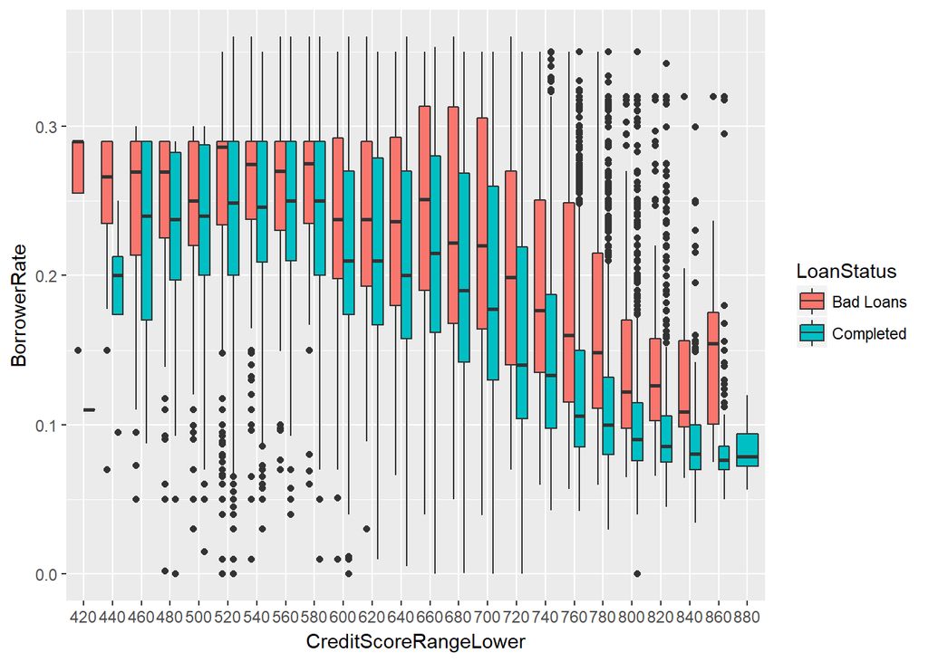

> We can see in the above plot that credit score is negatively correlated with borrower rate, and the borrower rate tends to be lower for completed loans. The discrepencies between borrower rates that were applied for completed loans and bad loans seem to be widen with higher credit score.

# Multivariate Analysis

### Some of the relationships observed in this part of the investigation. Were there features that strengthened each other in terms of looking at your feature(s) of interest?

> In this part, the relationship between credit score and loan status is examined. It is seen that the higer the credit score, the higher the probability that the loan is completed. This relationship is consistent across certain different groups of loans (with varied terms) and or borrowers (whether the borrower is a home owner or not).

### Were there any interesting or surprising interactions between features?

> The interactions between the features are in general intuitive, with the interactions between features that go against the common rules in loan governing.

# Final Plots and Summary

### Plot One

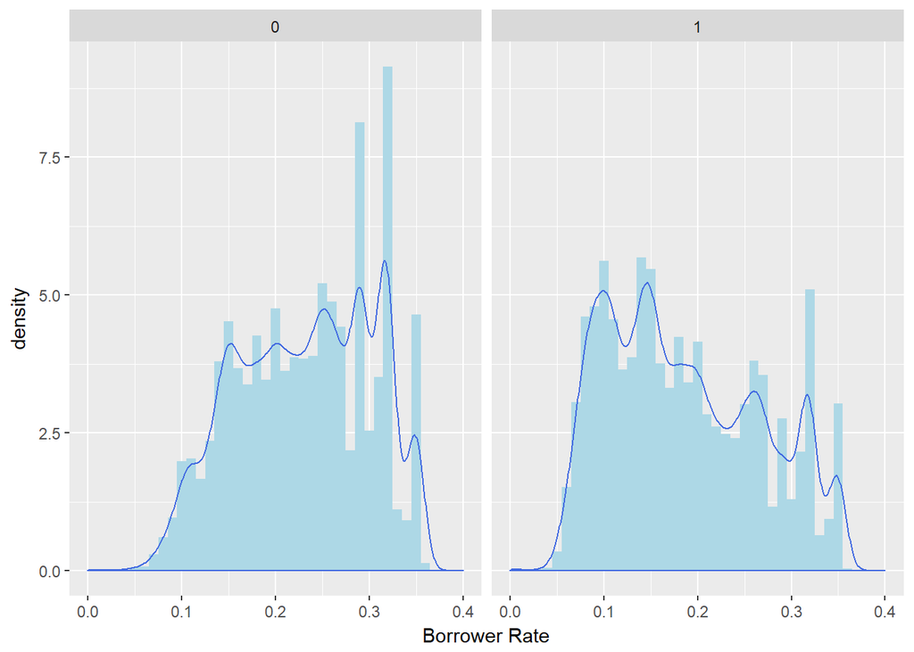

### Description One

> Plot one is the histograms showing the distribution of borrower rate in two groups: Completed Loans and Bad Loans. It shows that borrower rate of the Bad Loans group seems to be more skewed to the left, while that of the Completed Loans group appears to be more skewed to the right. It can imply that the borrower rates applied for Completed Loans tend to be lower.

### Plot Two

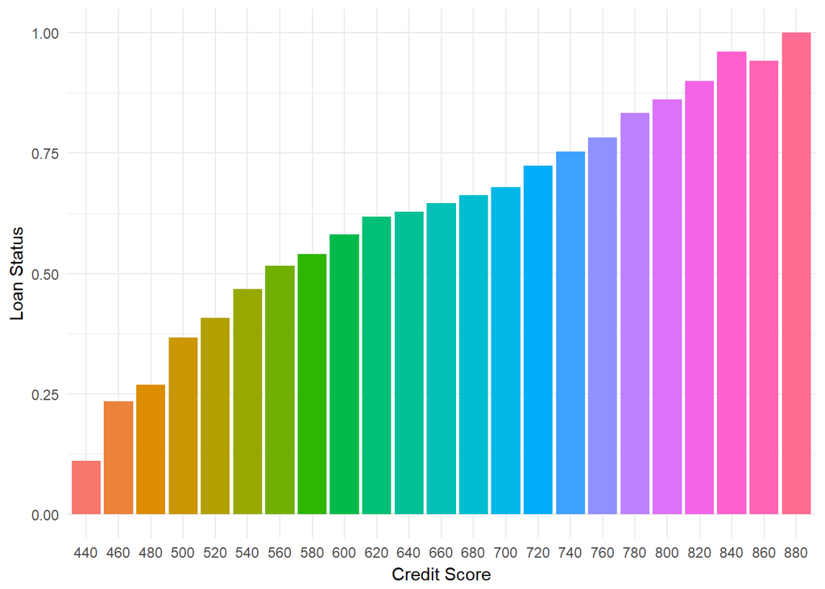

### Description Two

> Plot 2 shows the correlation between Credit Score and the probability of having Completed Loans. It demonstrates the positive correlation between Credit Score and Loan Status.

### Plot Three

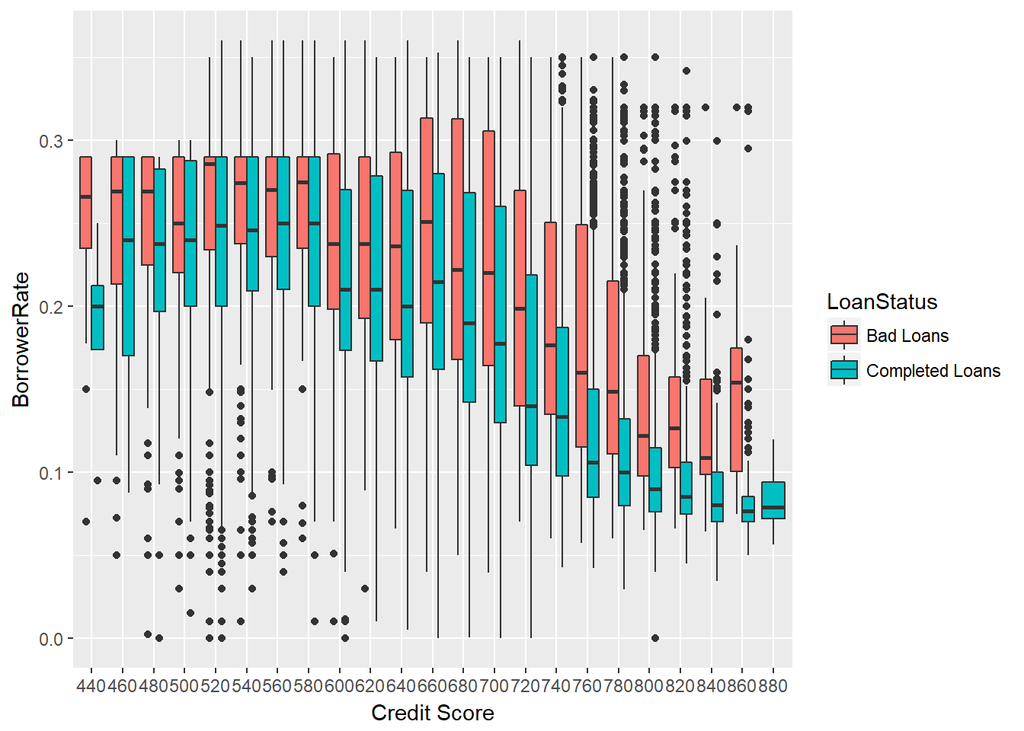

### Description Three

> Plot 3 presents the negative relationship between Credit Score and Borrower Rate. It also shows that the Borrower Rate tends to be lower for Completed Loans, and the discrepancies of Borrower Rates between Completed and Bad Loans seem to increase with higher credit score.

# Reflection

> The main question of interest when I explore this dataset is the relation between different variables to the probabilities of loan completion. Before conducting the exploratory analysis, I filled in missing values in certain columns. The first step is univariate analysis to understand the main variables of interest, including the depedent variable, Loan Status, and multiple independent variables in 4 main areas: Financial Information, Credit Score, Credit History and Loan Characteristics. The variables that are highly skewed are transformed using the log 10 base or limited to a certain range for better showing of the distribution.

> Next, the bivariate plots aims to answer the central question of this analysis by investigating how different variables relate to loan status. The multivariate plots provide some visualizations on the strongest relationships in different categorical groups. We find the correlation independent variables and loan status are intuitive and in line with basic principles of credit management.